# act_report

## Report: act_report

- Create a **250-word-minimum written report** called "act_report.pdf" or "act_report.html" that communicates the insights and displays the visualization(s) produced from your wrangled data. This is to be framed as an external document, like a blog post or magazine article, for example.

While wrangling the datas about `we rate dogs`, many questions come to me like the type of dog with the most like or retweetm the representation of purebred dog among the dogs `We rate dogs` tweet.

And after wrangling all these datas, my analysis and visualisation focused on these questions.

### The Insights after some observations and analysis:

I have discovered after analysing that :

1. The puppo and the doggo dogs are more liked . People like then, more doggo dogs which are on the way to become doggo since puppo is a transitional phase between pupper dand doggo
2. There are more purebred dogs in this dataset . Since purebred dogs are more represented, We rate dogs have surely used to tweet more about purebred dogs
3. Purebred dogs are more liked and retweeted. However the difference is not so big...

### Visualisation

I have choosen two types of charts for visualizing the results of the analysis

1. Let's visualize Representation of purebred and non-purebred dogs

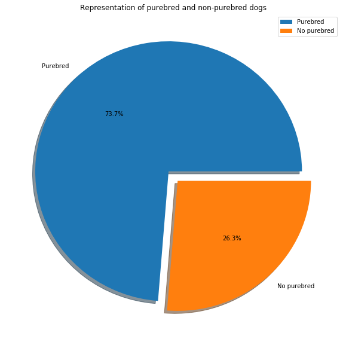

```python
%matplotlib inline
import pandas as pd

datas = pd.read_csv('twitter_archive_master.csv')

alt_datas_cleaned = datas.is_dog_purebred.apply(lambda x : "Purebred" if x==True else "No purebred")
alt_datas_cleaned.value_counts().plot(autopct='%1.1f%%', shadow=True, explode=[0.05, 0.05],use_index = False, kind='pie', figsize=(10, 10),legend = True, title = "Representation of purebred and non-purebred dogs", label = "");
```

- We noticed that 73.7% of dogs are purebred whereas 26.3% of dogs are not purebred dogs
- We can conclude that purebred dogs are most reprenseted in the archive of We rate dogs between 2015 and 2017
1. Let's visualize the mean of likes per dogs stage

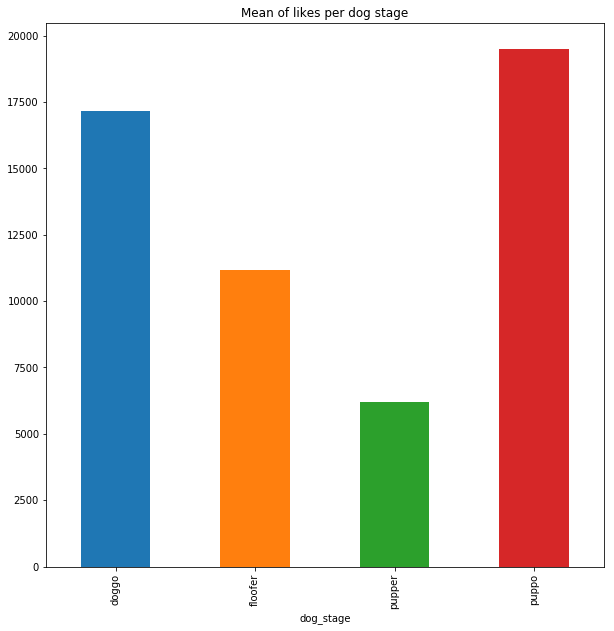

```python
datas.groupby('dog_stage')['likes_count'].mean().plot(kind = 'bar', figsize = (10,10), title = "Mean of likes per dog stage");
```

- Puppo and Doggo dogs have been more liked in average since 2015 until 2017
- In contrary, pupper dogs are those which have been less noted in average

I have not represent for a visualization,the analysis made for find out the relation between the number of likes and retweets and the dog breed(purebred or not) But there is no significant difference between the relativenumbers .